# GuangZongYaoZu

Shibo Dong, Ronghao Zhang, Linguo Yang, Ziqi Hao

22 April 2018

## Extract and tidy the data

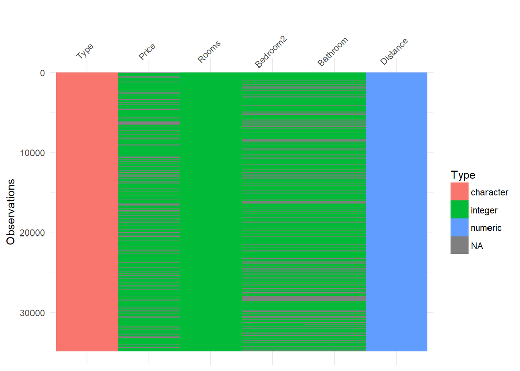

```r
library(tidyverse)
library(broom)

library(naniar)
houses <- read_csv("~/R/data/Melbourne_housing_FULL.csv")

houses <- houses %>%
  select(Price, Rooms, Type, Distance, Bedroom2, Bathroom)

library(visdat)
vis_dat(houses)
```

It can be seen that the missing values contribute a large proportion of data. If we directly drop all the missing value, the analysis will be significantly influenced. We need to impute these missing values to do most analyses.

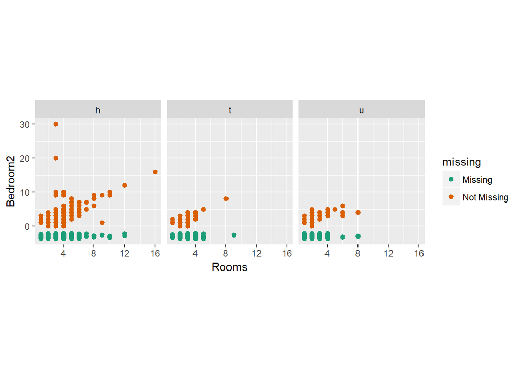

```r
ggplot(houses,
         aes(x = Rooms,
             y = Bedroom2)) +
  facet_wrap(~Type) +
  scale_color_brewer(palette="Dark2") +
  geom_miss_point() + theme(aspect.ratio = 1)
```

There is an obvious relationship between rooms and bedrooms, so the imputation should take account of the linear relationship between rooms and bedrooms.

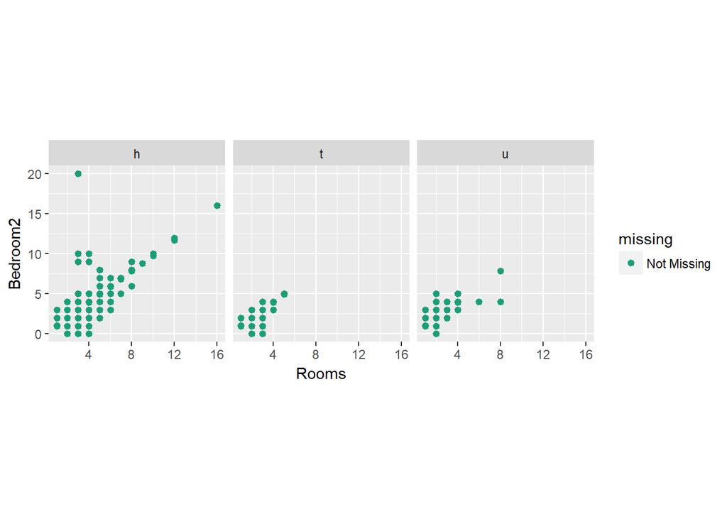

```r
tidy1 <- houses %>% filter(!is.na(Price))

tidy1 <- bind_shadow(tidy1)

br_lm <- lm(Bedroom2~Rooms, data=tidy1)
ba_lm <- lm(Bathroom~Rooms, data=tidy1)

tidy1 <- tidy1 %>%
  mutate(Bathroom = ifelse(is.na(Bathroom),
                        predict(ba_lm, .),
                        Bathroom)) %>%
  mutate(Bedroom2 = ifelse(is.na(Bedroom2),
                        predict(br_lm, .),
                        Bedroom2))

ggplot(tidy1,
         aes(x = Rooms,
             y = Bedroom2)) +
  facet_wrap(~Type) +
  scale_color_brewer(palette="Dark2") +
  geom_miss_point() + theme(aspect.ratio = 1)
```

```r
houses_tidy <- tidy1 %>%
  select(Price,Rooms,Type,Distance,Bedroom2,Bathroom) %>%
  mutate(Price = as.numeric(Price),
         Rooms = as.numeric(Rooms),
         Bedroom2 = as.numeric(Bedroom2),
         Bathroom = as.numeric(Bathroom)) %>%
  mutate(Type = factor(Type, ordered=FALSE)) %>%
  mutate(Price_million = Price/1000000)
```

Because The distribution of property price is right-skewed, we would better to transform it to log10 scale.

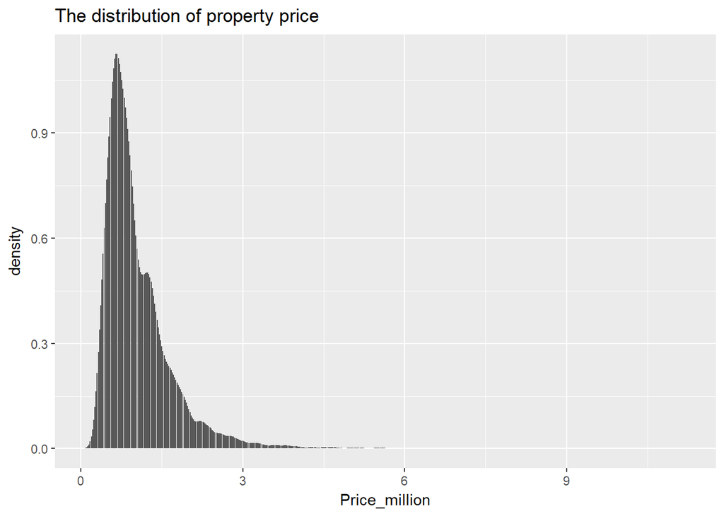

```r
ggplot(houses_tidy,
       aes(x=Price_million)) +
  geom_bar(stat = 'density') +
  ggtitle("The distribution of property price")
```

```r
houses_tidy <- houses_tidy %>%
  mutate(Price_million = log10(Price_million))

head(houses_tidy)
# A tibble: 6 x 7
    Price Rooms Type   Distance Bedroom2 Bathroom Price_million
    <dbl> <dbl> <fctr>    <dbl>    <dbl>    <dbl>         <dbl>
1 1480000  2.00 h          2.50     2.00     1.00        0.170
2 1035000  2.00 h          2.50     2.00     1.00        0.0149
3 1465000  3.00 h          2.50     3.00     2.00        0.166
4  850000  3.00 h          2.50     3.00     2.00       -0.0706
5 1600000  4.00 h          2.50     3.00     1.00        0.204
6  941000  2.00 h          2.50     2.00     1.00       -0.0264
```

## Plot the data

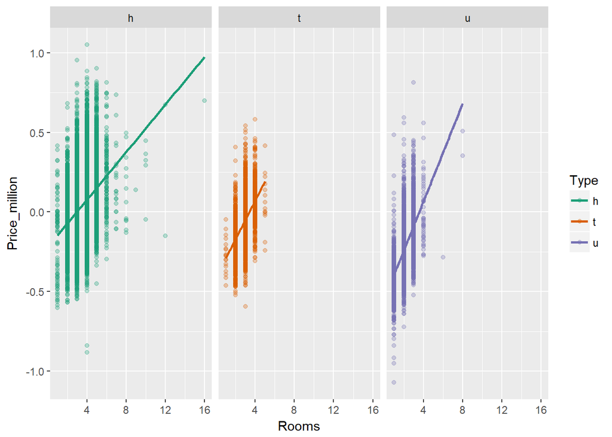

```r
ggplot(houses_tidy, aes(x=Rooms, y=Price_million,
                            colour=Type)) +
  geom_point(alpha=0.3) +
  scale_colour_brewer(palette = "Dark2") +
  facet_wrap(~Type) +
  geom_smooth(method="lm", se=FALSE)
```

Apparently, There is an linear relationship between the number of rooms and Price per million in all three type of property.

## Modelling

```r
mod1 <- lm(Price_million ~ Rooms*Type, data = houses_tidy)
tidy(mod1)
         term    estimate   std.error  statistic       p.value
1 (Intercept) -0.22191368 0.005418032 -40.958354  0.000000e+00
2       Rooms  0.07468772 0.001580268  47.262704  0.000000e+00
3       Typet -0.18962632 0.015762260 -12.030402  2.986799e-33
4       Typeu -0.32464511 0.009514007 -34.122858 6.199943e-250
5 Rooms:Typet  0.04598135 0.005233746   8.785553  1.645564e-18
6 Rooms:Typeu  0.07900155 0.004020568  19.649351  2.286745e-85
```

we can assume that Model 1 has an interaction. This means that the slope will be allowed to vary for the different levels of the categorical variable, Type.

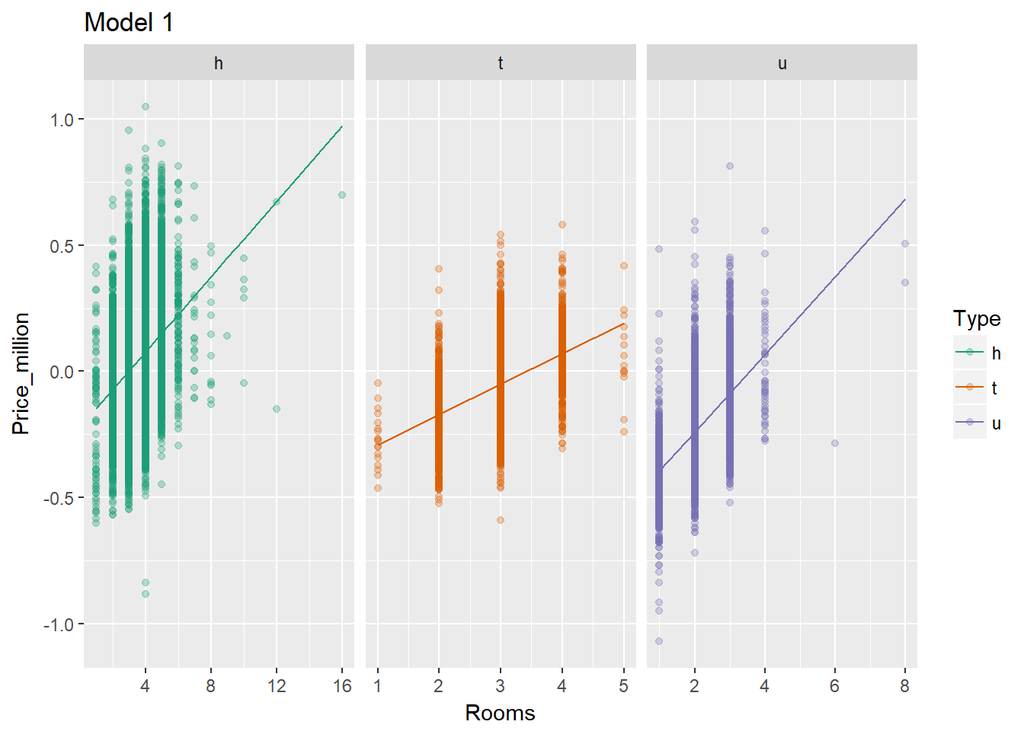

```r
hou_mod1 <- augment(mod1, houses_tidy)
ggplot(houses_tidy, aes(x=Rooms, y=Price_million,
                        colour=Type)) +
  geom_point(alpha=0.3) +
  scale_colour_brewer(palette = "Dark2") +
  facet_wrap(~Type,scales = "free_x") +
  geom_line(data = hou_mod1, aes(y=.fitted)) +
  ggtitle("Model 1")
```

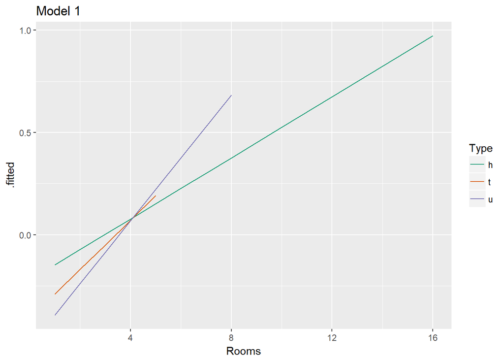

```r
ggplot(hou_mod1, aes(x=Rooms, y=.fitted,
                           colour=Type)) +
  geom_line() +
  scale_colour_brewer("Type", palette="Dark2") +
  ggtitle("Model 1")
```

It also verified our assumption, which indicates an interaction between the number of rooms and types of property.

```r
glance(mod1)
  r.squared adj.r.squared     sigma statistic p.value df   logLik
1 0.3372794     0.3371578 0.1827909  2772.761       0  6 7645.074
        AIC       BIC deviance df.residual
1 -15276.15 -15218.66 910.1901       27241
```

The r.squared is much lower than expected. What we need to do is add one more variable into the model and compare which model is better to use.

```r
mod2 <- lm(Price_million ~ Rooms*Type+Distance, data = houses_tidy)
tidy(mod2)
         term    estimate    std.error statistic       p.value
1 (Intercept) -0.11341987 0.0048327665 -23.46893 1.334981e-120
2       Rooms  0.09447205 0.0013853986  68.19124  0.000000e+00
3       Typet -0.20367035 0.0136621768 -14.90761  4.635197e-50
4       Typeu -0.38051773 0.0082668765 -46.02920  0.000000e+00
5    Distance -0.01410742 0.0001485166 -94.98886  0.000000e+00
6 Rooms:Typet  0.04539528 0.0045361638  10.00742  1.552800e-23
7 Rooms:Typeu  0.09094924 0.0034869498  26.08275 3.780420e-148
```

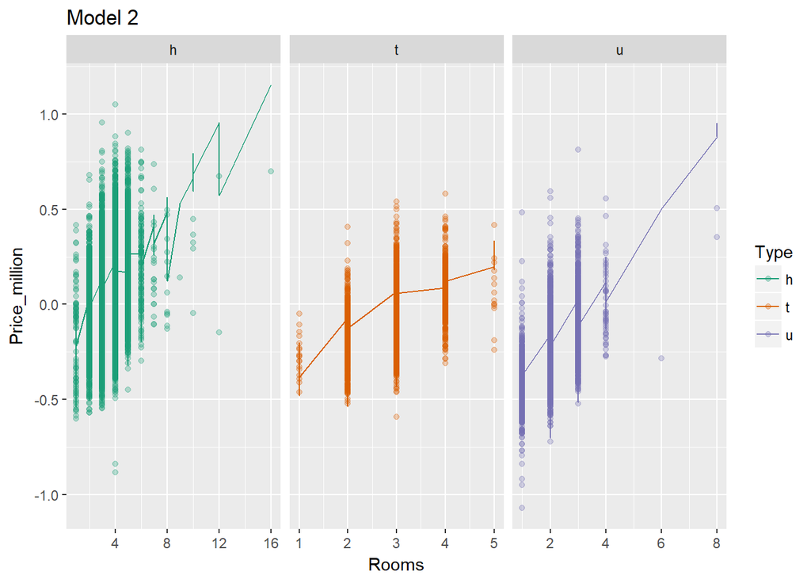

```r
hou_mod2 <- augment(mod2, houses_tidy)
ggplot(houses_tidy, aes(x=Rooms, y=Price_million,
                        colour=Type)) +
  geom_point(alpha=0.3) +
  scale_colour_brewer(palette = "Dark2") +
  facet_wrap(~Type,scales = "free_x") +
  geom_line(data = hou_mod2, aes(y=.fitted)) +
  ggtitle("Model 2")
```

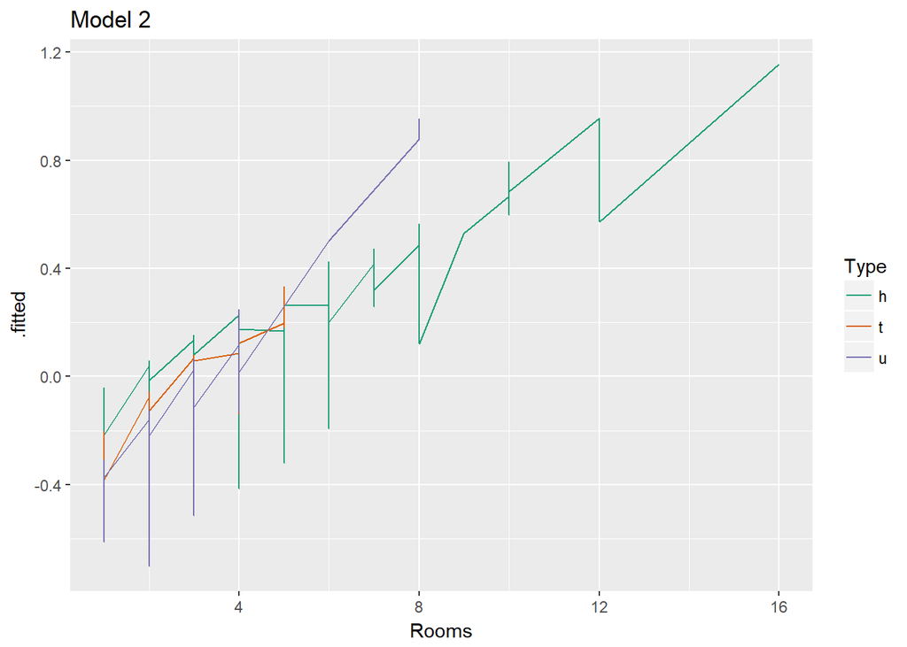

```r
ggplot(hou_mod2, aes(x=Rooms, y=.fitted,
                           colour=Type)) +
  geom_line() +
  scale_colour_brewer("Type", palette="Dark2") +
  ggtitle("Model 2")
```

```r
glance(mod2)
  r.squared adj.r.squared     sigma statistic p.value df   logLik
1 0.5021955     0.5020858 0.1584273  4579.877       0  7 11542.75
        AIC       BIC deviance df.residual
1 -23069.49 -23003.79 683.6776       27239
```

The r.squared for model 2 is much higher and its deviance is kind of smaller than model 1. Thus, model 2 is more reasonable and better for prediction.

## Diagnostic

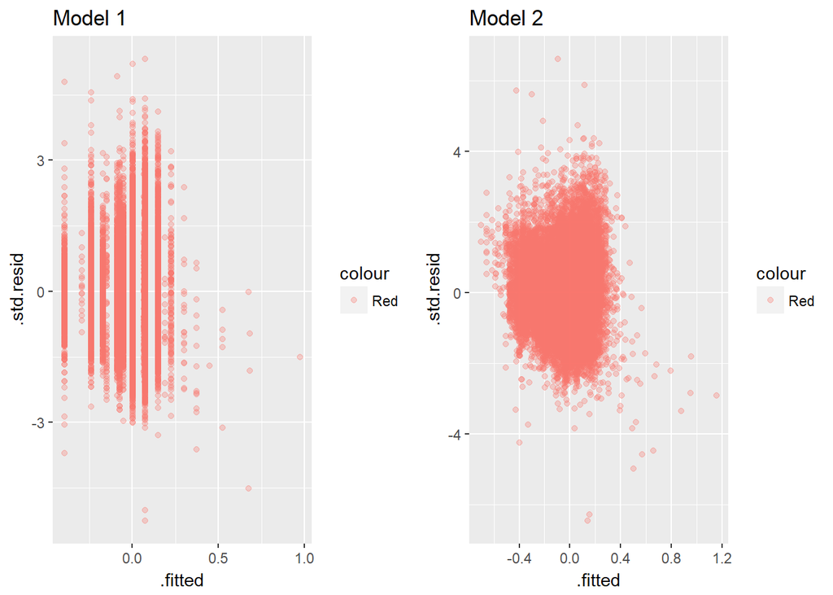

```r
library(gridExtra)
p1 <- ggplot(hou_mod1, aes(x=.fitted, y=.std.resid,
                           color="Red")) +
  geom_point(alpha=0.3) +
  ggtitle("Model 1")
p2 <- ggplot(hou_mod2, aes(x=.fitted, y=.std.resid,
                           color="Red")) +
  geom_point(alpha=0.3) +
  ggtitle("Model 2")
grid.arrange(p1, p2, ncol=2)
```